# Intro_to_ShortRead

Xuening

7/6/2020

Package `ShortRead` deals with fasta and fastq file.

## fasta file

Each sequence in fasta format takes 2 lines:  
> unique_sequence_identifier  
raw_sequence_string

```r
library(ShortRead)

# read fasta
fasasample <- readFasta("covid19_sequence.fasta")
fasasample
```

```
## class: ShortRead
## length: 1 reads; width: 29800 cycles
```

```r
id(fasasample)
```

```
##   A BStringSet instance of length 1
##     width seq
## [1]   117 MT676397.1 Severe acute respirator...IND/GBRC189/2020, complete genome
```

```r
length(fasasample)
```

```
## [1] 1
```

```r
width(fasasample)
```

```
## [1] 29800
```

## fastq

Each read in fastq format contains 4 lines:  
@ unique_sequence_identifier  
raw_sequence_string  
+ optional id  
quality encoding per sequence letter

```r
# read Fastq file
fq <- readFastq("SRR1971253.fastq")
fq
```

```
## class: ShortReadQ
## length: 500 reads; width: 50 cycles
```

```r
id(fq)
```

```
##   A BStringSet instance of length 500
##       width seq
##   [1]    63 SRR1971253.55828 HS2:546:C4DUWACXX:3:2310:19006:63818 length=50
##   [2]    63 SRR1971253.37947 HS2:546:C4DUWACXX:3:2113:13109:84610 length=50
##   [3]    62 SRR1971253.15442 HS2:546:C4DUWACXX:3:1210:6648:68689 length=50
##   [4]    62 SRR1971253.31075 HS2:546:C4DUWACXX:3:2102:9495:71119 length=50
##   [5]    62 SRR1971253.4534 HS2:546:C4DUWACXX:3:1109:10996:45700 length=50
##   ...   ... ...
## [496]    63 SRR1971253.43593 HS2:546:C4DUWACXX:3:2207:12387:52082 length=50
## [497]    63 SRR1971253.59528 HS2:546:C4DUWACXX:3:2315:19766:42624 length=50
## [498]    62 SRR1971253.27308 HS2:546:C4DUWACXX:3:1313:3461:13904 length=50
## [499]    62 SRR1971253.37657 HS2:546:C4DUWACXX:3:2113:7202:45293 length=50
## [500]    62 SRR1971253.45211 HS2:546:C4DUWACXX:3:2210:7640:18421 length=50
```

```r
# sample Fastq file
set.seed(1)
fs <- FastqSampler("SRR1971253.fastq",n=5)
fq_sample <- yield(fs)
fq_sample
```

```
## class: ShortReadQ
## length: 5 reads; width: 50 cycles
```

We can get the first read using function `sread()`.

```r
sread(fq_sample)[1]
```

```
##   A DNAStringSet instance of length 1
##     width seq
## [1]    50 TGTTGTGGGCCGAGTTCGATCCGACCACGTGCACGCTGTCGGCTGAGGAC
```

## Sequence quality

Quality value $Q=-log(error\_rate)$. The quality of each base is encoded by a character. We can extract quality encoding from fastq file using `quality()`.

```r
quality(fq_sample)
```

```
## class: FastqQuality
## quality:
##   A BStringSet instance of length 5
##     width seq
## [1]    50 CCCFFDFFHGHHGJHIJJJJJJJCHIDGIBFHJIJJJJIJJIGGFFFDDD
## [2]    50 CCCFFFFFGHHHHIJIIIJJJHIGICHHIEGGIGHHHIIHFFFCEEEBBB
## [3]    50 ?:=;4A3@@ADDDGI>DECFHEHIIIBCB@BCFCFEFFB<DFC??FGFII
## [4]    50 CBCFFFFFHHHHGJJHIJIJJJJJJJIJJJIJHIIIJJJJJJJIJJHHFF
## [5]    50 @B@FDFDFFHHFFIIGGIIHHHIJJIHGIJBGIGIJIJGIHIFEEHHFFF
```

We can know the meaning of each encoding character using function `PhredQuality()`

```r
PhredQuality(1:40)
```

```
##   A PhredQuality instance of length 1
##     width seq
## [1]    40 "#$%&'()*+,-./0123456789:;<=>?@ABCDEFGHI
```

We can get the integer scores.

```r
# convert FastqQuality class to PhredQuality class
pq <- PhredQuality(quality(fq_sample))
pq
```

```
##   A PhredQuality instance of length 5
##     width seq
## [1]    50 CCCFFDFFHGHHGJHIJJJJJJJCHIDGIBFHJIJJJJIJJIGGFFFDDD
## [2]    50 CCCFFFFFGHHHHIJIIIJJJHIGICHHIEGGIGHHHIIHFFFCEEEBBB
## [3]    50 ?:=;4A3@@ADDDGI>DECFHEHIIIBCB@BCFCFEFFB<DFC??FGFII
## [4]    50 CBCFFFFFHHHHGJJHIJIJJJJJJJIJJJIJHIIIJJJJJJJIJJHHFF
## [5]    50 @B@FDFDFFHHFFIIGGIIHHHIJJIHGIJBGIGIJIJGIHIFEEHHFFF
```

```r
qs <- as(pq,"IntegerList")
qs
```

```
## IntegerList of length 5
## [[1]] 34 34 34 37 37 35 37 37 39 38 39 39 ... 41 41 40 38 38 37 37 37 35 35 35
## [[2]] 34 34 34 37 37 37 37 37 38 39 39 39 ... 39 37 37 37 34 36 36 36 33 33 33
## [[3]] 30 25 28 26 19 32 18 31 31 32 35 35 ... 27 35 37 34 30 30 37 38 37 40 40
## [[4]] 34 33 34 37 37 37 37 37 39 39 39 39 ... 41 41 41 41 40 41 41 39 39 37 37
## [[5]] 31 33 31 37 35 37 35 37 37 39 39 37 ... 40 39 40 37 36 36 39 39 37 37 37
```

A score larger than 30 is considered good quality.

## Quality assessment

```r
qaSummary <- qa(fq_sample,lane=1)
qaSummary
```

```
## class: ShortReadQQA(10)
## QA elements (access with qa[["elt"]]):
##   readCounts: data.frame(1 3)
##   baseCalls: data.frame(1 5)
##   readQualityScore: data.frame(512 4)
##   baseQuality: data.frame(95 3)
##   alignQuality: data.frame(1 3)
##   frequentSequences: data.frame(5 4)
##   sequenceDistribution: data.frame(1 4)
##   perCycle: list(2)
##     baseCall: data.frame(151 4)
##     quality: data.frame(172 5)
##   perTile: list(2)
##     readCounts: data.frame(0 4)
##     medianReadQualityScore: data.frame(0 4)
##   adapterContamination: data.frame(1 1)
```

```r
names(qaSummary)
```

```
##  [1] "readCounts"           "baseCalls"            "readQualityScore"
##  [4] "baseQuality"          "alignQuality"         "frequentSequences"
##  [7] "sequenceDistribution" "perCycle"             "perTile"
## [10] "adapterContamination"
```

ShortReadQQA elements are accessed with qaSummary[[“name”].

```r
qaSummary[["baseCalls"]]
```

```
##    A  C  G  T N
## 1 55 65 64 66 0
```

```r
qaSummary[["readQualityScore"]]
```

```
##      quality      density lane type
## 1   33.09140 3.419295e-03    1 read
## 2   33.10540 4.013953e-03    1 read
## 3   33.11941 4.693850e-03    1 read
## 4   33.13342 5.463525e-03    1 read
## 5   33.14742 6.330700e-03    1 read
## 6   33.16143 7.328851e-03    1 read
## 7   33.17543 8.476955e-03    1 read
## 8   33.18944 9.762122e-03    1 read
## 9   33.20345 1.119444e-02    1 read
## 10  33.21745 1.279094e-02    1 read
## 11  33.23146 1.463106e-02    1 read
## 12  33.24547 1.666668e-02    1 read
## 13  33.25947 1.890944e-02    1 read
## 14  33.27348 2.137104e-02    1 read
```

[output cut: 498 more lines]

To get a HTML report, use `browseURL()`.

```r
browseURL(report(qaSummary))
```

## Alphabet by cycle

Knowing how many A,C, G, T is added to all reads at each round can be important.

```r
alphabet(sread(fq_sample))
```

```
##  [1] "A" "C" "G" "T" "M" "R" "W" "S" "Y" "K" "V" "H" "D" "B" "N" "-" "+" "."
```

```r
abc <- alphabetByCycle(sread(fq_sample))
abc
```

```
##         cycle
## alphabet [,1] [,2] [,3] [,4] [,5] [,6] [,7] [,8] [,9] [,10] [,11] [,12] [,13]
##        A    1    1    1    0    0    1    1    2    0     2     1     0     2
##        C    0    1    1    2    2    0    2    0    2     1     4     0     1
##        G    1    1    0    2    2    3    2    2    2     1     0     2     1
##        T    3    2    3    1    1    1    0    1    1     1     0     3     1
##        M    0    0    0    0    0    0    0    0    0     0     0     0     0
##        R    0    0    0    0    0    0    0    0    0     0     0     0     0
##        W    0    0    0    0    0    0    0    0    0     0     0     0     0
##        S    0    0    0    0    0    0    0    0    0     0     0     0     0
##        Y    0    0    0    0    0    0    0    0    0     0     0     0     0
##        K    0    0    0    0    0    0    0    0    0     0     0     0     0
##        V    0    0    0    0    0    0    0    0    0     0     0     0     0
##        H    0    0    0    0    0    0    0    0    0     0     0     0     0
##        D    0    0    0    0    0    0    0    0    0     0     0     0     0
##        B    0    0    0    0    0    0    0    0    0     0     0     0     0
##        N    0    0    0    0    0    0    0    0    0     0     0     0     0
##        -    0    0    0    0    0    0    0    0    0     0     0     0     0
##        +    0    0    0    0    0    0    0    0    0     0     0     0     0
##        .    0    0    0    0    0    0    0    0    0     0     0     0     0
##         cycle
## alphabet [,14] [,15] [,16] [,17] [,18] [,19] [,20] [,21] [,22] [,23] [,24]
##        A     0     0     1     2     2     3     4     0     1     1     1
##        C     2     1     1     1     0     1     0     2     2     1     1
##        G     2     2     0     1     2     1     0     1     1     2     1
##        T     1     2     3     1     1     0     1     2     1     1     2
##        M     0     0     0     0     0     0     0     0     0     0     0
##        R     0     0     0     0     0     0     0     0     0     0     0
##        W     0     0     0     0     0     0     0     0     0     0     0
##        S     0     0     0     0     0     0     0     0     0     0     0
##        Y     0     0     0     0     0     0     0     0     0     0     0
##        K     0     0     0     0     0     0     0     0     0     0     0
##        V     0     0     0     0     0     0     0     0     0     0     0
##        H     0     0     0     0     0     0     0     0     0     0     0
##        D     0     0     0     0     0     0     0     0     0     0     0
##        B     0     0     0     0     0     0     0     0     0     0     0
##        N     0     0     0     0     0     0     0     0     0     0     0
##        -     0     0     0     0     0     0     0     0     0     0     0
##        +     0     0     0     0     0     0     0     0     0     0     0
##        .     0     0     0     0     0     0     0     0     0     0     0
```

[output cut: 45 more lines]

```
##        T     1     0     0     3
##        M     0     0     0     0
##        R     0     0     0     0
##        W     0     0     0     0
##        S     0     0     0     0
##        Y     0     0     0     0
##        K     0     0     0     0
##        V     0     0     0     0
##        H     0     0     0     0
##        D     0     0     0     0
##        B     0     0     0     0
##        N     0     0     0     0
##        -     0     0     0     0
##        +     0     0     0     0
##        .     0     0     0     0
```

```r
# only first 4 rows are ATCG
nucByCycle <- t(abc[1:4,])

# convert to tibble
library(dplyr)
nucByCycle <- nucByCycle %>% as_tibble() %>%mutate(cycle=1:50) # add circle number
nucByCycle
```

```
## # A tibble: 50 x 5
##        A     C     G     T cycle
##    <int> <int> <int> <int> <int>
##  1     1     0     1     3     1
##  2     1     1     1     2     2
##  3     1     1     0     3     3
##  4     0     2     2     1     4
##  5     0     2     2     1     5
##  6     1     0     3     1     6
##  7     1     2     2     0     7
##  8     2     0     2     1     8
##  9     0     2     2     1     9
## 10     2     1     1     1    10
## # … with 40 more rows
```

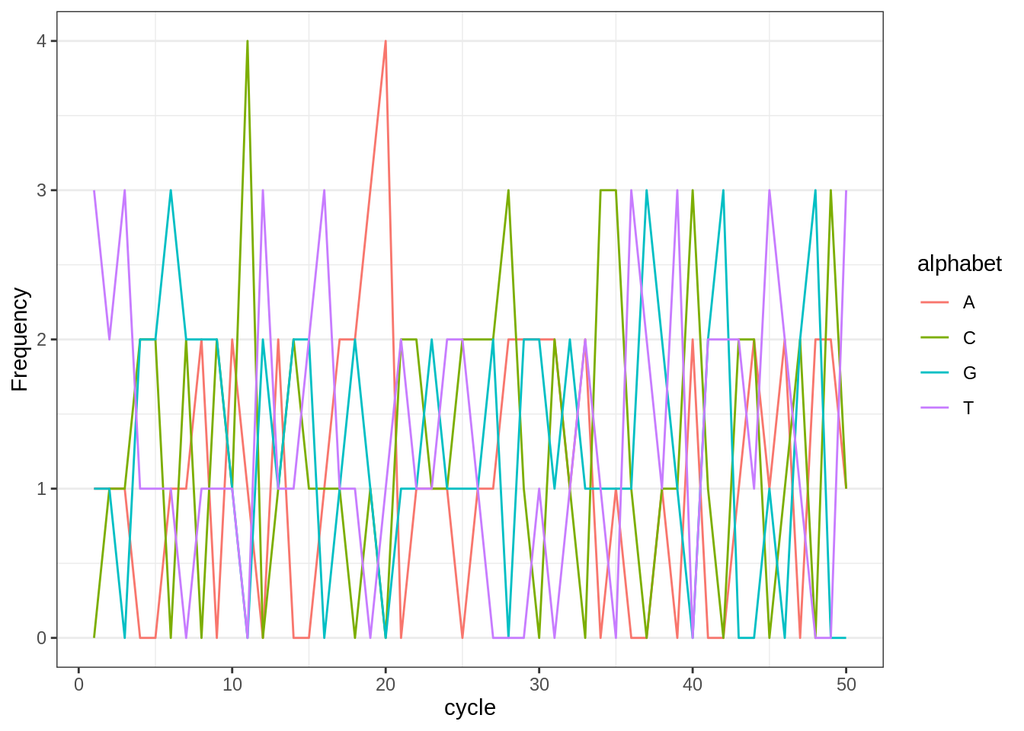

```r
# investigate how alphabet frequency change with cycle
library(tidyverse)
library(ggplot2)
nucByCycle %>%
  # Gather the nucleotide letters in alphabet and get a new count column
  gather(key = alphabet, value = count , -cycle) %>%
  ggplot(aes(x = cycle, y =  count, color = alphabet)) +
  geom_line(size = 0.5 ) +
  labs(y = "Frequency") +
  theme_bw() +
  theme(panel.grid.major.x = element_blank())
```

## Check for duplicates

```r
table(srduplicated(fq_sample))
```

```
##
## FALSE
##     5
```

## Filter

Filters can be used to subset a `ShortReadQ` object, or directly to a fastq file.

`nFilter()` has a threshold parameter, representing the maximum number of “N”s allowed on each read.

```r
my_filter <- nFilter(threshold=10)
fq_sample[my_filter(fq_sample)]
```

```
## class: ShortReadQ
## length: 5 reads; width: 50 cycles
```

```r
# use the filter when reading
filtered_fq <- readFastq("SRR1971253.fastq",filter=my_filter)
filtered_fq
```

```
## class: ShortReadQ
## length: 500 reads; width: 50 cycles
```

`idFilter()` uses a regular expression to select specific ids.

```r
my_idfilter <- idFilter(regex=":3:1")
filtered_fq <-readFastq("SRR1971253.fastq",filter=my_idfilter)
filtered_fq
```

```
## class: ShortReadQ
## length: 257 reads; width: 50 cycles
```

```r
ShortRead::id(filtered_fq)[1]
```

```
##   A BStringSet instance of length 1
##     width seq
## [1]    62 SRR1971253.15442 HS2:546:C4DUWACXX:3:1210:6648:68689 length=50
```

```r
my_polyA_filter <- polynFilter(threshold=10,nuc=c("A"))
filtered_fq <-readFastq("SRR1971253.fastq",filter=my_polyA_filter)
filtered_fq
```

```
## class: ShortReadQ
## length: 198 reads; width: 50 cycles
```

`srFilter()` is a function to create our own filter.

```r
read_with_cutoff <- srFilter(function(x) {width(x)>minWidth},name='MinWidth')
minWidth <- 51
fq_sample[read_with_cutoff(fq_sample)]
```

```
## class: ShortReadQ
## length: 0 reads; width:  cycles
```